# class09

Seth McNeely

2/4/2020

## K-means clustering

The main k-means function is called `kmeans()`. Let’s play with it here. First, we need to generate some data.

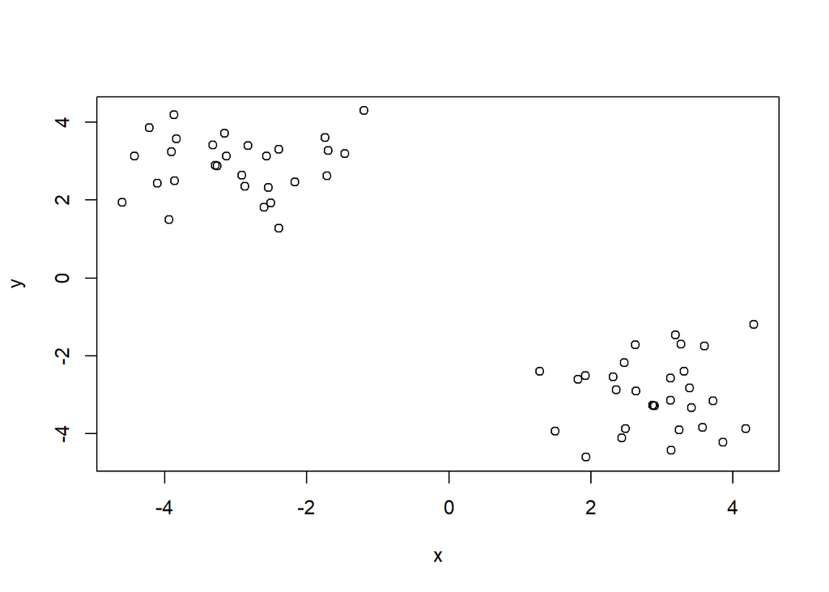

```r
# Generate some example data for clustering
tmp <- c(rnorm(30,-3), rnorm(30,3))
x <- cbind(x=tmp, y=rev(tmp))

plot(x)
```

Now let’s see how `kmeans()` actually works.

```r
# Find clusters with two centers and twenty iterations
kx <- kmeans(x, centers=2, nstart=20)
kx
```

```
## K-means clustering with 2 clusters of sizes 30, 30
##
## Cluster means:
##           x         y
## 1 -2.993102  2.894597
## 2  2.894597 -2.993102
##
## Clustering vector:
##  [1] 1 1 1 1 1 1 1 1 1 1 1 1 1 1 1 1 1 1 1 1 1 1 1 1 1 1 1 1 1 1 2 2 2 2 2 2 2 2
## [39] 2 2 2 2 2 2 2 2 2 2 2 2 2 2 2 2 2 2 2 2 2 2
##
## Within cluster sum of squares by cluster:
## [1] 40.6357 40.6357
##  (between_SS / total_SS =  92.8 %)
##
## Available components:
##
## [1] "cluster"      "centers"      "totss"        "withinss"     "tot.withinss"
## [6] "betweenss"    "size"         "iter"         "ifault"
```

Inspecting the results:

Q1. How many points are in each cluster? `K-means clustering with 2 clusters of sizes 30, 30`

We can use the `kx$cluster` tag to call our cluster data

```r
kx$cluster
```

```
##  [1] 1 1 1 1 1 1 1 1 1 1 1 1 1 1 1 1 1 1 1 1 1 1 1 1 1 1 1 1 1 1 2 2 2 2 2 2 2 2
## [39] 2 2 2 2 2 2 2 2 2 2 2 2 2 2 2 2 2 2 2 2 2 2
```

```r
length(kx$cluster)
```

```
## [1] 60
```

```r
table(kx$cluster)
```

```
##
##  1  2
## 30 30
```

Now let’s replot using our cluster data

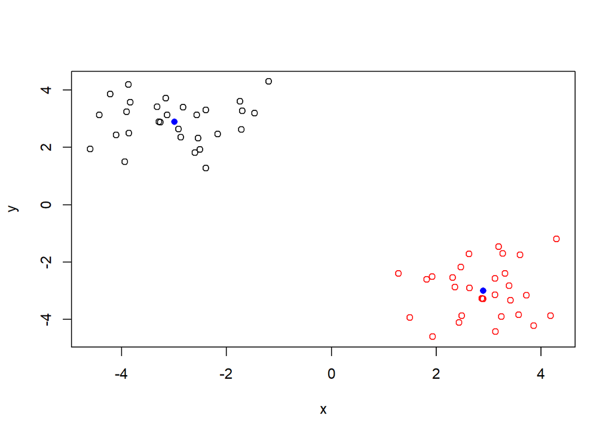

```r
# Plot x colored by the kmeans cluster assignment and add cluster centers as blue points
plot(x, col=kx$cluster)
points(kx$centers, col="blue", pch=16)
```

## Hierarchical clustering

The main hierarchical clustering fucntion in R is `hclust`. An important point here is that you have to calculate the distance matrix from your input data before calling.

For this, we can use the `dist()`

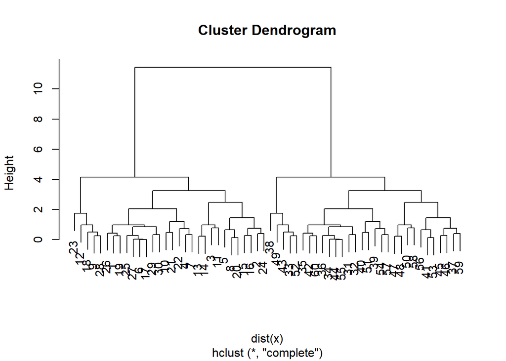

```r
hc <- hclust(dist(x))
plot(hc)
```

We can add more features to our tree by cutting our tree into its membership groups:

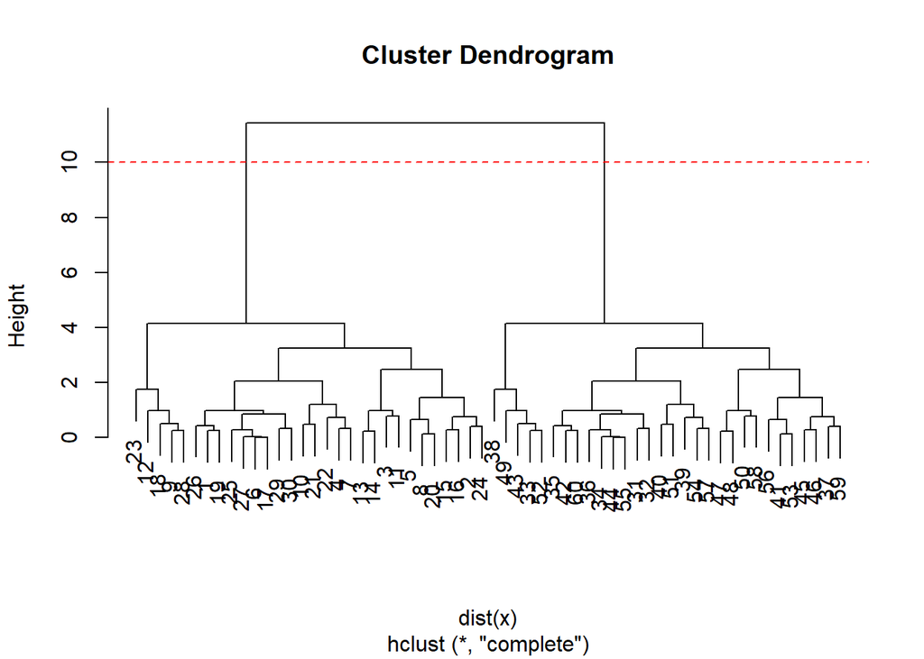

```r
plot(hc)
abline(h=10, col="red", lty=2)
```

```r
cutree(hc, h=10) # Cut by height h
```

```
##  [1] 1 1 1 1 1 1 1 1 1 1 1 1 1 1 1 1 1 1 1 1 1 1 1 1 1 1 1 1 1 1 2 2 2 2 2 2 2 2
## [39] 2 2 2 2 2 2 2 2 2 2 2 2 2 2 2 2 2 2 2 2 2 2
```

```r
# h= argument can be changed to k= if you want to cut by a specific number of groups
```

## Let’s try with some more serious data.

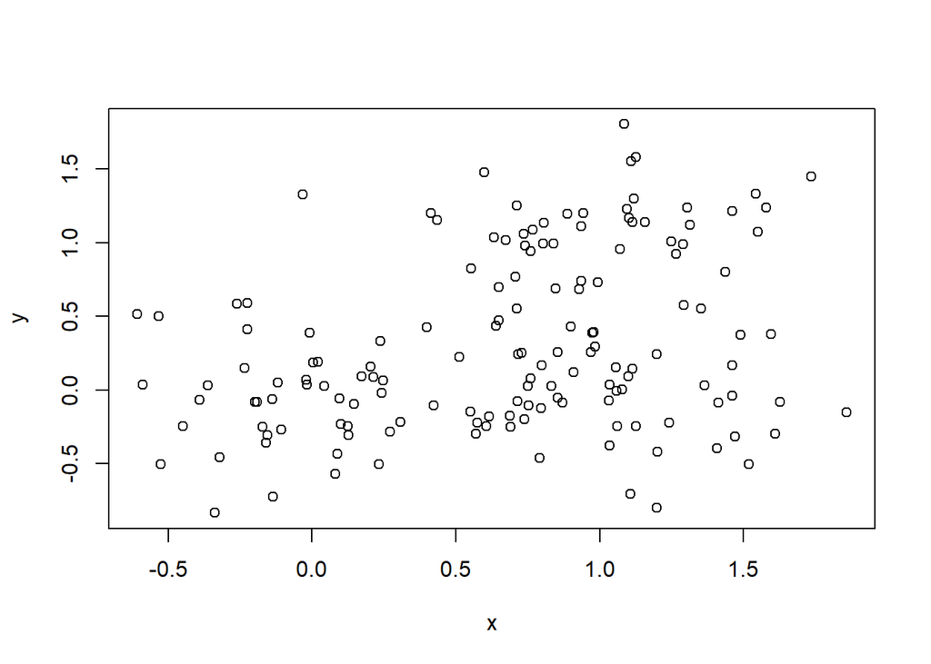

```r
# Step 1. Generate some example data for clustering
x <- rbind(
 matrix(rnorm(100, mean=0, sd = 0.3), ncol = 2), # c1
 matrix(rnorm(100, mean = 1, sd = 0.3), ncol = 2), # c2
 matrix(c(rnorm(50, mean = 1, sd = 0.3), # c3
 rnorm(50, mean = 0, sd = 0.3)), ncol = 2))

colnames(x) <- c("x", "y")

# Step 2. Plot the data without clustering
plot(x)
```

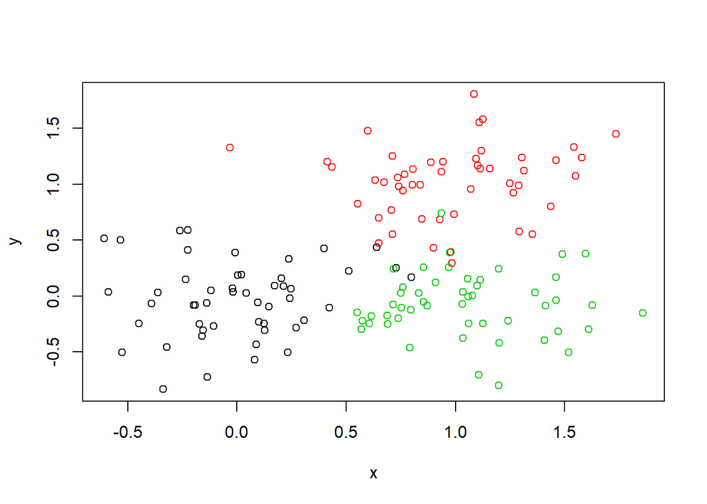

```r
# Step 3. Generate colors for known clusters
# (just so we can compare to hclust results)
col <- as.factor( rep(c("c1","c2","c3"), each=50) )

plot(x, col=col)
```

Inspecting the results:

Q1. Use the `dist()`, `hclust()`, `plot()`, and `cutree()` functions to return 2 and 3 clusters

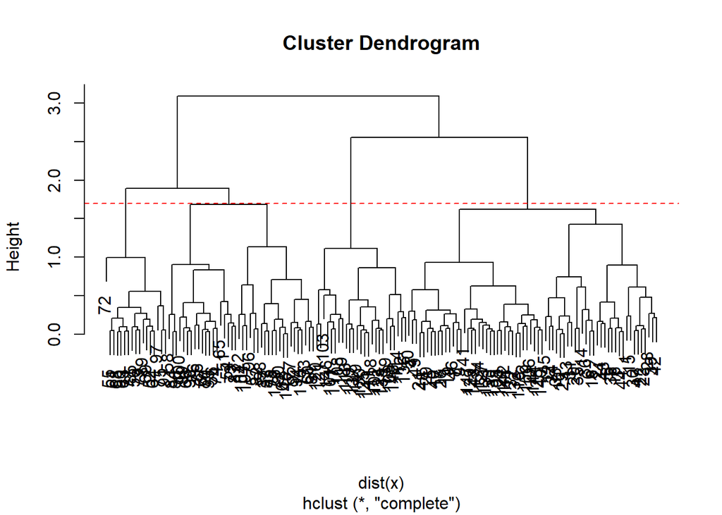

```r
hc <-  hclust(dist(x))
plot(hc)
abline(h=1.7, col="red", lty=2)
```

To get cluster memberships vector, use `cutree()` and then `table()` to find how many members in each cluster. We can also plot our data with our new groupings.

```r
grps <- cutree(hc, k=3)
table(grps)
```

```
## grps
##  1  2  3
## 68 57 25
```

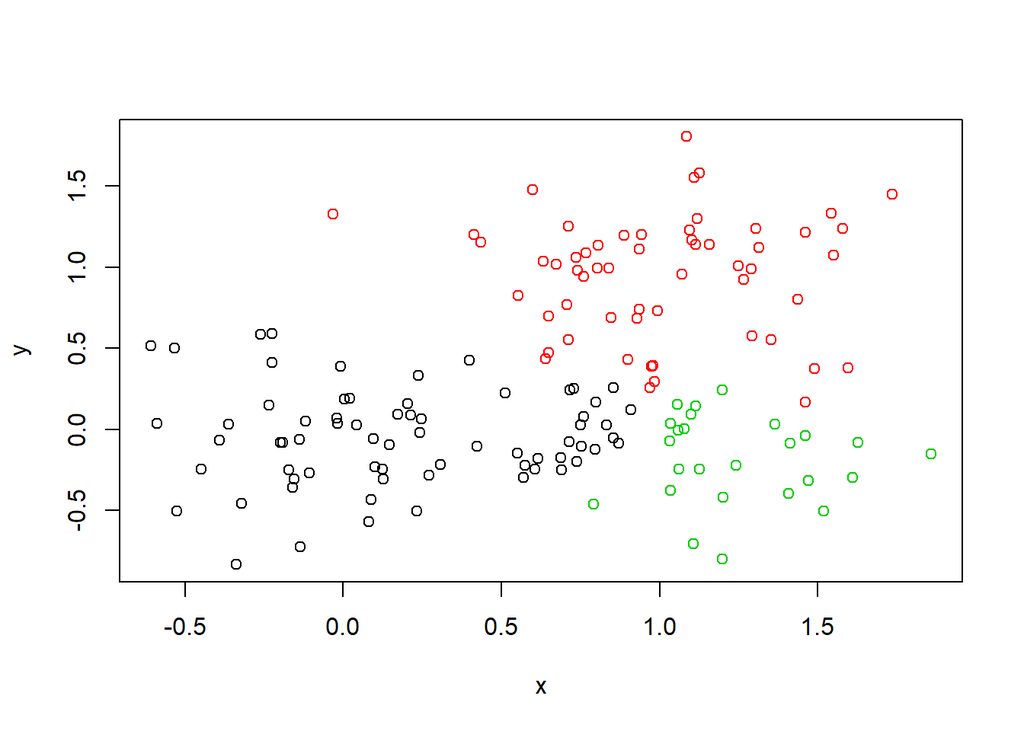

```r
plot(x, col=grps)
```

Q2. How does this compare to your known ‘col’ groups? Notice how no colors are intersecting with another grouping unlike before.